# USDR Appointment Availability Data - New Jersey

Last compiled at 2021-07-16 17:03

**TLDR**

- Vaccine appointments are less available and available for less time in the weekends and outside of working hours.
- Zip-codes with a higher social vulnerability index have less appointment availability.
- Appointment availability is positively correlated with vaccinations.

**Background**

In this report we take cursory look at slot-level COVID appointment availability data as gathered by USDR’s [UNIVAF](http://getmyvax.org/docs/) project. The main question we’re looking at is whether this kind of data can be used to identify issues in vaccine access by different demographics. Another question is whether this can help us understand the role of barriers to access, as opposed to more ideological barriers, can help us understand trailing vaccination rates.

- This report pertains to *slot-level* appointment data only. We often don’t have slot-level data, so this covers a subset of appointments.
- We take as the interval a slot is available for as the time between the first time we saw it being available to the last time.
- ‘work time’ is defined as Mon-Fri 9am-5pm.
- For slots we compute the following statistics:
  1. how many slots are ever seen to be available for that hour
  2. how long (in number of hours) are they available for on average
  3. the relative prominence of weekend slots (as compared to slots during the weekday)

Stats:

- There are 1142 locations in our DB. Of these, 328 have slot-level data (29%).
- `valid_at` range is from 2021-05-19 16:37:00 to 2021-06-30 21:25:00.
- `slot_time` range is from 2021-05-19 18:00:00 to 2021-06-30 21:45:00.

Provider breakdown:

```
##
##     njvss walgreens   walmart
##      1260    226388     24985
```

## Coverage (county)

Roughly, what share of vaccinations can be traced to “bookings” in our appointment availability data? This is a very coarse estimate that smooths over a lot of uncertainties like: when do shots get counted? what about doses? can appointments get overbooked? do they get canceled? Keeping these uncertainties in mind, here is the distribution of the coverage rate by county, as compared to the national distribution:

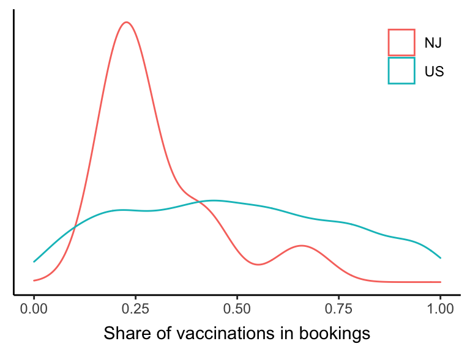

- Most counties seem to have an approximately 25% coverage rate.

Here are the number of slots per day (weekend days highlighted), whether they were “booked”, and how long they were available for:

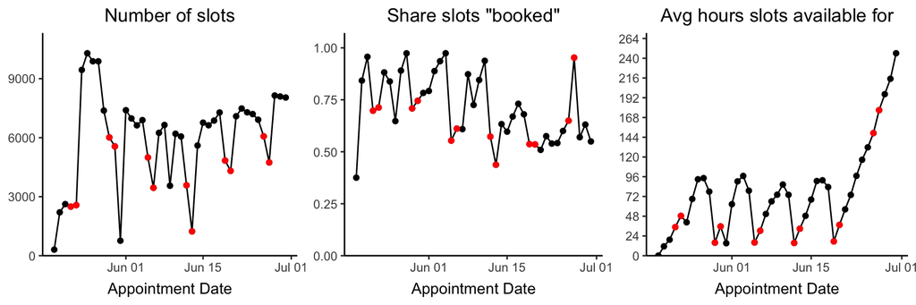

## Appointment availability over time (state)

### Number of slots

Total number of slots that were ever available, unwrapped by dates. Mondays are highlighted:

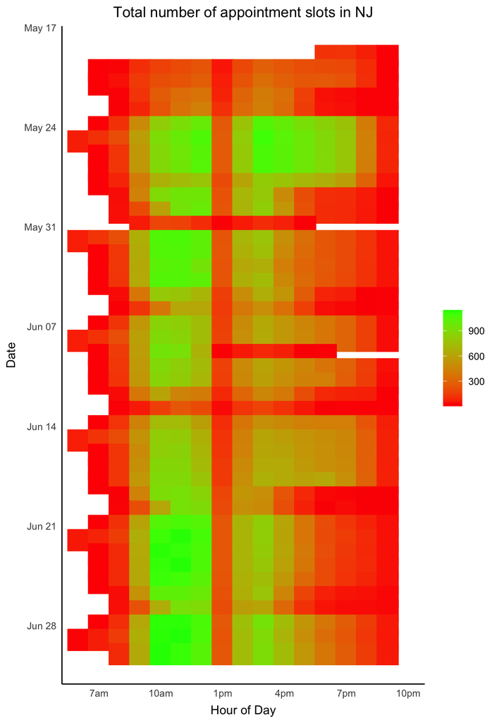

- Availability has been better since the week of May 24th
- Less availability outside of the work day and outside working hours in the weekend.

Aggregate stats per provider:

| Provider | Number of Slots | Avg. hours available | Relative weekend slots |
| --- | --- | --- | --- |
| njvss | 1260 | 3.4 | 0.64 |
| walgreens | 226388 | 96.7 | 0.71 |
| walmart | 24985 | 2.4 | 0.53 |

- Statistics will be mostly driven by Walgreens.

### Average hours slots are available for

Average number of hours that slots are available for. More is better as it gives the person more time to book an appointment.

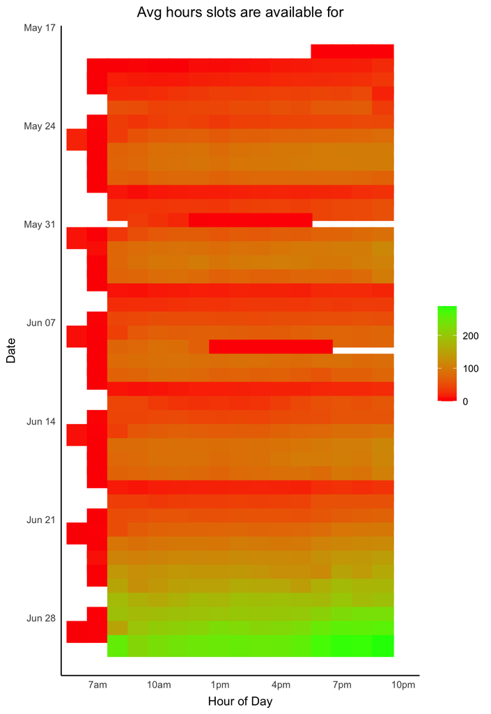

- The last week sees a big increase in time available for, as the release schedule switched from weekly on Friday to daily two weeks in advance.
- Contrary to the national average, evening slots do *not* seem to be harder to book day day time slots.

Averaged by hour of day and day of week:

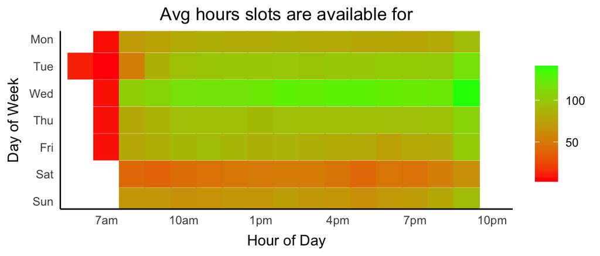

- Slots outside working hours are available for a shorter amount of time.

## Availability by convenience (state)

Here are the aggregate statistics for slots at different times. Morning is before 9am, evening is after 5pm.

```
## # A tibble: 4 x 5
##   type          n p_booked range last_time_ahead
##   <fct>     <int>    <dbl> <dbl>           <dbl>
## 1 workday 8999396    0.593  98.7            9.06
## 2 morning  368560    0.687  67.8            8.94
## 3 evening 2248340    0.312  57.6            5.84
## 4 weekend 2794851    0.475  55.1            7.64
```

## Availability (county)

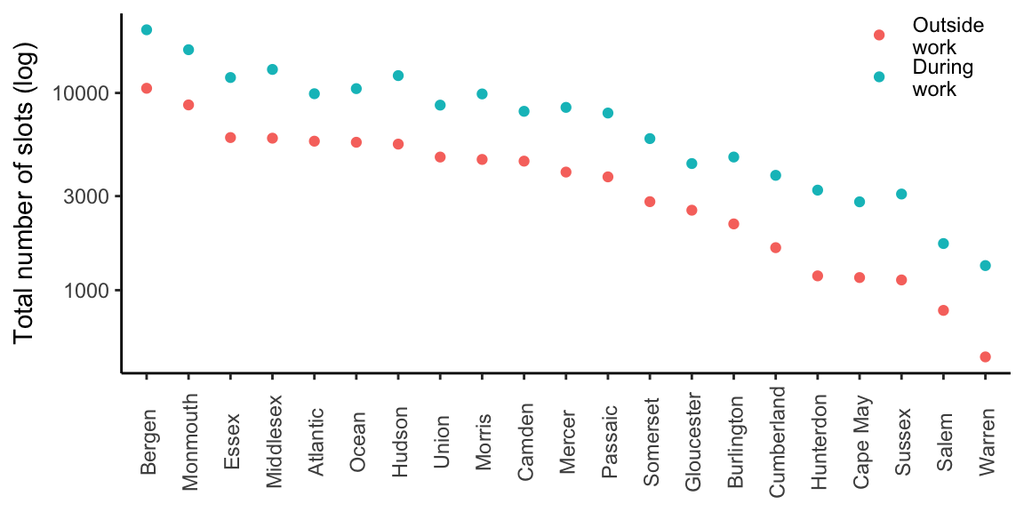

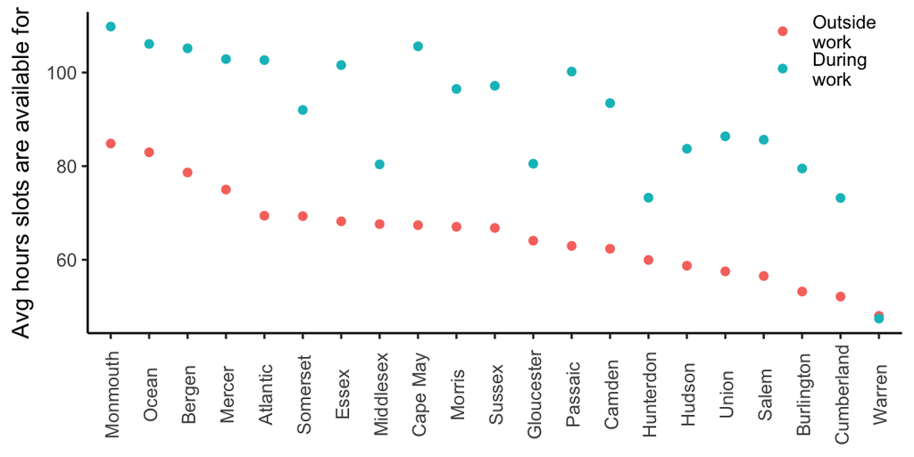

- No strong trends, except for that slots during the workday are more available, and available for longer.

## Availability by vulnerability (zip)

We can compare appointment availability by the demographics of the area that the distribution location is in. The most granular level is the zip-code. Of course, people can travel to locations outside of their zip-code, and so a better analysis would, for every zip code, take an average of the nearby locations weighted by their distance.

We do univariate correlations between vulnerability indices like SVI and availability statistics. In this plot, the points represent individual zip-codes in NJ. The red line is a linear fit of the relationship between the vulnerability statistic and the availbility statistic. The blue line represents that same relationship for all zipcodes in the US.

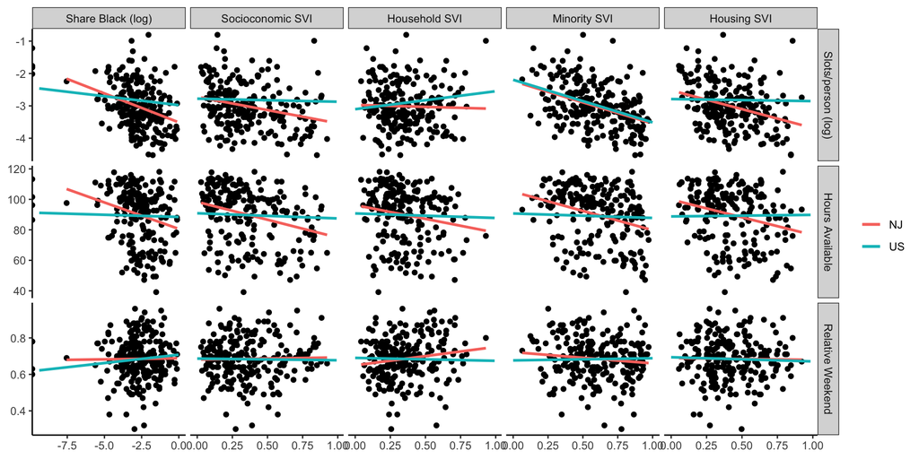

For most indices, we see a **negative correlation between vulnerability and availability** (household SVI excluded), and the trend for NJ is a bit worse than the national average.

*Note*: because we don’t have vaccination data on the zip-code level, we can’t (unlike below for counties) adjust slots/person by coverage, nor can we plot the SVI statistics against vaccination rates on a zip-code level.

## Does availability predict vaccinations? (county)

How does appointment availability relate to vaccinations? Unfortunately we don’t have vaccination data on the zip-code level, so we’ll do this analysis on a county level. Vaccination counts by county by day are pulled from [CovicActNow.org](https://covidactnow.org/). The outcome we look at is the *difference in vaccination rate* over the six weeks that we’re looking at. We run a simple linear regression with counties as units. First just the availability statistics, and then taking into account other drivers like hesitancy (taken from [this](https://data.cdc.gov/Vaccinations/Vaccine-Hesitancy-for-COVID-19-County-and-local-es/q9mh-h2tw/data) CDC survey and prior vaccination rate).

```
##
## =====================================================
##                              Dependent variable:
##                         -----------------------------
##                               n_vax/population
##                            (1)       (2)       (3)
## -----------------------------------------------------
## Slots/Person (week)     1.026***            0.703***
##                          (0.256)             (0.214)
## Slots/Person (weekend)   -0.093             -2.361**
##                          (1.147)             (0.858)
## Average range (hrs)      0.0003              0.0001
##                         (0.0002)            (0.0001)
## Share Black                        -0.132*  -0.110**
##                                    (0.063)   (0.051)
## Trump vote share                  -0.200*** -0.180***
##                                    (0.042)   (0.041)
## % hesitant (CDC survey)            -0.273     0.003
##                                    (0.234)   (0.214)
## Prior vax rate                     -0.001*   -0.0004
##                                    (0.001)  (0.0005)
## Intercept                -0.034   0.268***   0.161**
##                          (0.025)   (0.050)   (0.073)
## -----------------------------------------------------
## Observations               21        21        21
## Adjusted R2               0.608     0.748     0.852
## =====================================================
## Note:                     *p<0.1; **p<0.05; ***p<0.01
```